# Supervised Learning Workflow: Regression and Classification

Model selection and evaluation across a continuous and a categorical outcome

Josh Lyons

# Regression: Predicting species richness

## Exploratory Data Analysis

The Weil 2021 dataset contains ecological measurements from mountain grassland plots in the French Alps, including plant traits, soil properties and climate variables. The prediction task is to model species richness (`spnm`) using the remaining predictors, which include both continuous ecological measurements and a categorical gradient variable describing the site.

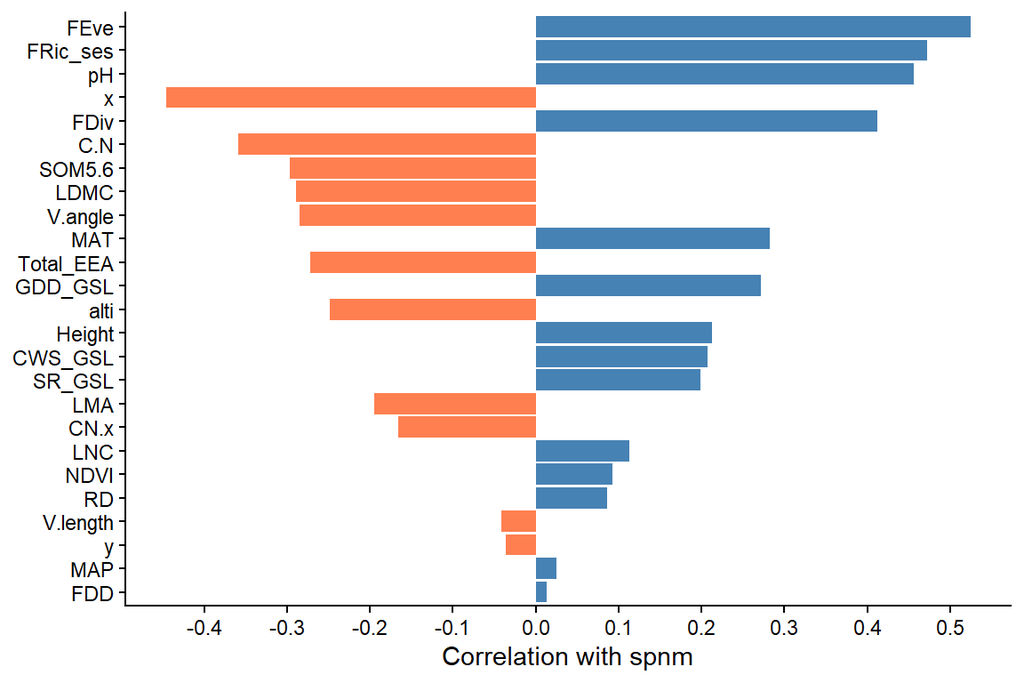

**Figure 1:** Pearson correlation of each predictor with species richness (spnm), ordered by absolute correlation magnitude. Blue bars indicate positive correlations, coral bars indicate negative correlations.

Table 1: Species richness distribution across gradients.

**Weil 2021** via Dryad

| Gradient | Total obs. | Mean | SD | Min | Max |
| --- | --- | --- | --- | --- | --- |
| ANT | 3 | 48.00 | 12.29 | 34 | 57 |
| ARG | 3 | 52.33 | 17.62 | 32 | 63 |
| ARM | 4 | 68.00 | 14.45 | 55 | 81 |
| BON | 3 | 48.67 | 9.07 | 42 | 59 |
| CHAM | 2 | 59.00 | 5.66 | 55 | 63 |
| DEV | 3 | 68.33 | 11.72 | 55 | 77 |
| LAU | 5 | 59.00 | 10.02 | 45 | 69 |
| MON | 1 | 55.00 | NA | 55 | 55 |
| NEV | 3 | 46.00 | 3.00 | 43 | 49 |
| PAI | 3 | 37.33 | 5.03 | 32 | 42 |
| RBI | 3 | 66.67 | 13.87 | 55 | 82 |
| TEN | 2 | 43.50 | 3.54 | 41 | 46 |
| VAN | 3 | 62.67 | 5.51 | 59 | 69 |
| VCHA | 3 | 42.00 | 5.57 | 36 | 47 |

Table 1 shows that mean species richness varied considerably across gradients, ranging from 37.3 to 68.3, indicating that gradient was likely to be an informative predictor. Sample sizes per gradient were small, with most sites having only 2–5 observations and one gradient having a single observation.

## Subset Selection and Shrinkage

### Forward Stepwise Selection

Forward stepwise selection was used, which starts from the null model and adds one predictor at a time. Best subset selection was infeasible with approximately 38 predictors, requiring 2^38 models to be fitted. Backward stepwise requires n > p and while technically satisfied here, with n = 41 and approximately 38 predictors the margin was too small for the method to be reliable.

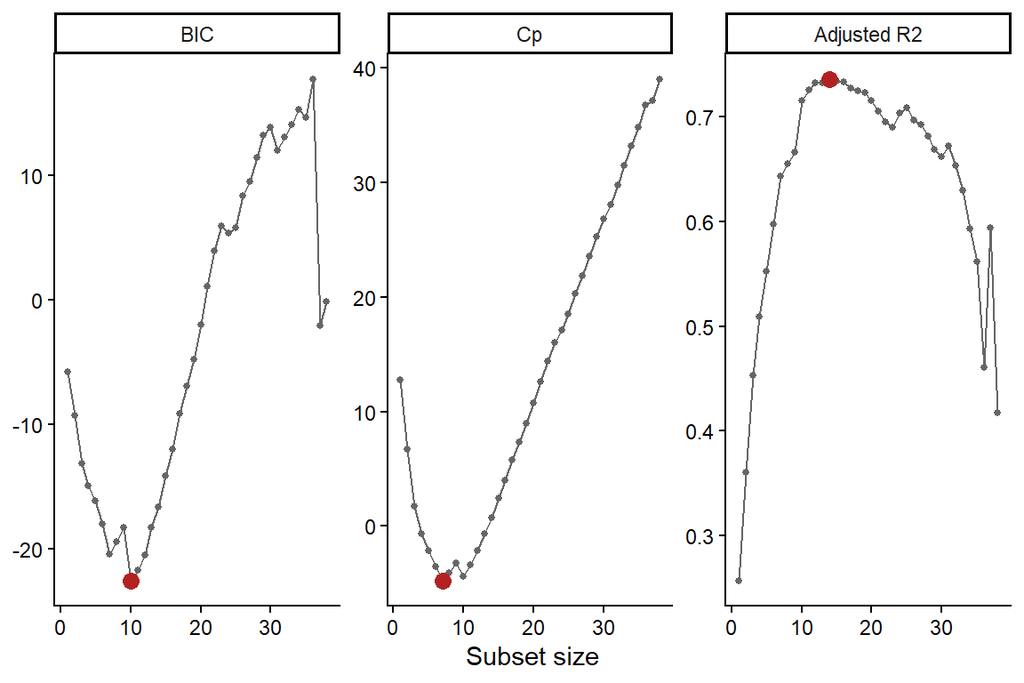

**Figure 2:** BIC, Cp and adjusted R² against subset size for forward stepwise selection. Red points mark the optimum under each criterion.

BIC was used to select the subset size, as its heavier penalty per predictor discourages overfitting in small samples. Cp suggested a slightly smaller model than BIC at 7 predictors, which was an unexpected inversion given BIC’s heavier penalty to complexity, while adjusted R² favoured a much larger model, consistent with its tendency to over select. The BIC curve suggested that a model of 7 predictors was within 2 units of the global minimum at 10 predictors, which was not considered sufficient evidence to prefer the more complex model, so p = 7 was selected. The LOOCV RMSE for the subset selection model was 8.96 species.

### Lasso Regression

Lasso regression was used as the shrinkage method. Lasso applies an L1 penalty that simultaneously shrinks coefficients toward zero and can set some exactly to zero, performing both shrinkage and variable selection in a single step. Ridge regression applies an L2 penalty that shrinks all coefficients but never sets any to zero, retaining all predictors regardless of their relevance. This made lasso more appropriate for this dataset since the EDA showed that most predictors had weak correlations with species richness, suggesting that many would benefit from shrinkage, while several had correlations near zero, suggesting they should be excluded entirely.

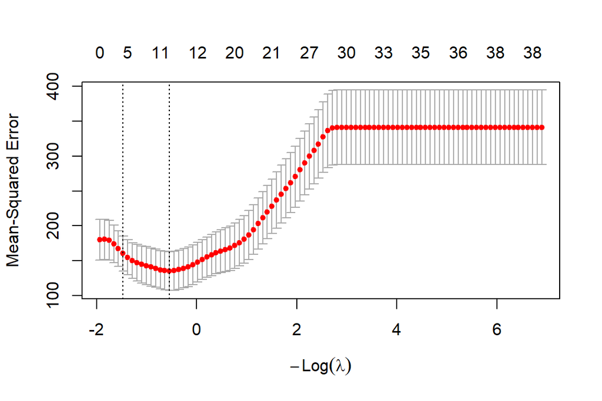

**Figure 3:** 10-fold CV MSE against log(lambda) for the lasso. Dashed lines indicate lambda.min and lambda.1se.

The CV curve showed a relatively flat minimum across a range of lambda values. At the lambda that minimised CV error the model retained 11 predictors, while the largest lambda within one standard error of the minimum retained 4 predictors. The difference in RMSE between the two was approximately 1 species, which was not considered sufficient to justify the more complex model, so the more parsimonious lambda was selected. The LOOCV RMSE for the lasso model was 12.6 species.

## Bootstrap Confidence Interval for a Key Predictor

`FRic_ses` was selected as it showed one of the strongest positive correlations with species richness in the EDA, appeared in both models and had the largest coefficient in both by a considerable margin, suggesting it has the strongest association with species richness after accounting for other predictors.

Table 2: Bootstrap 99% CI for correlation between `FRic_ses` and species richness

**Weil 2021** via Dryad

| Predictor | Correlation | Bootstrap SE | 99% CI Lower | 99% CI Upper |
| --- | --- | --- | --- | --- |
| FRic_ses | 0.4724 | 0.1116 | 0.1689 | 0.7169 |

The 99% confidence interval does not include zero, providing evidence of a genuine positive association between functional richness and species richness. The confidence interval is fairly wide, which is expected given the small sample size of 41 observations and shows the uncertainty around the point estimate of correlation.

## Model Comparison

The subset selection model achieved a LOOCV RMSE of 8.96 species compared to 12.6 species for lasso, a meaningful difference suggesting subset selection generalised considerably better on this dataset. Despite performing less accurately, the lasso retained a notably sparser model of just `x`, `FRic_ses`, `FEve` and `pH` compared to the seven predictors retained by subset selection: `x`, `RD`, `FRic_ses`, `FEve`, `pH`, `MAT` and `gradientPAI`. The signs of the shared coefficients agreed between both methods, with `x` negative and `FRic_ses`, `FEve` and `pH` positive. The consistent selection of `FRic_ses`, `FEve` and `pH` across two fundamentally different methods provides stronger evidence that these predictors have genuine associations with species richness than either method alone would suggest.

# Classification: Predicting in-hospital mortality

## Exploratory Data Analysis

The Zhou 2021 dataset contains clinical measurements for 1176 patients admitted to an ICU with heart failure, with the goal of predicting in-hospital mortality. The dataset is considerably imbalanced with 1017 survivors and 159 deaths, which is important context for interpreting model performance.

Table 3: Comorbidity prevalence by patient outcome

**Zhou 2021** via Dryad

| Comorbidity | % of Survivors | % of Deaths |
| --- | --- | --- |
| hypertensive | 73.1 | 63.5 |
| atrialfibrillation | 43.2 | 57.9 |
| diabetes | 43.1 | 35.8 |
| Hyperlipemia | 39.0 | 31.4 |
| Renal failure | 38.5 | 23.3 |
| deficiencyanemias | 35.8 | 22.0 |
| CHD with no MI | 8.8 | 7.5 |
| depression | 12.7 | 6.9 |
| COPD | 8.1 | 4.4 |

The comorbidity table showed that most conditions were more prevalent in survivors than deaths, which likely reflects the class imbalance rather than a genuine protective effect. The notable exception was atrial fibrillation, which was more common in patients who died (57.9%) than those who survived (43.2%), suggesting a genuine association with mortality risk.

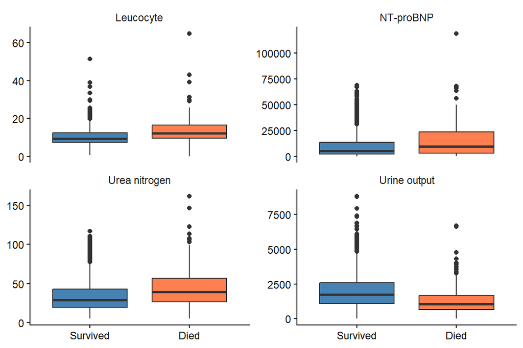

**Figure 4:** Distribution of the four continuous predictors with the largest mean difference between survivors and deaths. Variables were selected by ranking all continuous predictors by percentage difference in means between outcome groups.

The boxplots showed that patients who died tended to have higher `NT-proBNP`, `Urea nitrogen` and `Leucocyte` values and lower `Urine output` than survivors, suggesting these variables may carry some useful predictive information. However, all four variables showed considerable overlap between groups and a number of extreme outliers, suggesting these differences alone are unlikely to be sufficient for reliable classification.

## Hyperparameter Tuning

### Decision Tree

The number of terminal nodes was tuned using cross-validation with misclassification error as the criterion. The single node solution was excluded as it represents a degenerate model that simply predicts the majority class for all observations, which provides no useful discrimination between outcomes. The optimal size was 3 terminal nodes, reflecting that a simple tree with few splits was sufficient to capture the main signal in the training data. The small optimal size may also reflect the class imbalance, where the tree quickly learns to predict survival for most observations.

### Random Forest

The `mtry` parameter was tuned by evaluating out-of-bag error across all possible values, averaged over 10 repeated runs to reduce instability. The optimal value was 21, which is higher than the rule of thumb of √p ≈ 6 for classification, possibly reflecting that having more predictors available at each split helps the forest find the rare signal associated with deaths given the class imbalance.

### Linear Discriminant Analysis

The posterior probability threshold for classifying observations as deaths was tuned using 10-fold cross-validation, selecting the threshold that minimised overall CV error. A threshold of 0.57 was selected, close to the default of 0.5, reflecting that the class imbalance caused the model to achieve its lowest overall error by predicting survival for most observations.

### K-Nearest Neighbours

Predictors were standardised prior to fitting since KNN is distance-based. The number of neighbours k was tuned using 10-fold cross-validation, with 8 selected. KNN is known to struggle with class imbalance since the majority class tends to dominate the neighbourhood, which may limit its ability to identify deaths in this dataset.

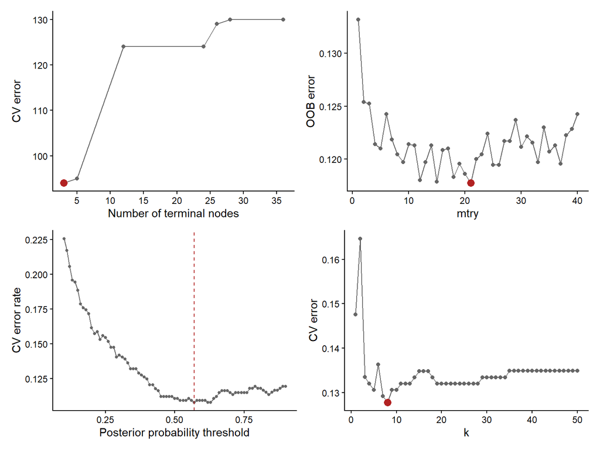

**Figure 5:** Hyperparameter tuning results for each of the four classification models. Red points or dashed lines indicate the selected hyperparameter.

## Results

Table 4: Classification model performance on the test set

**Zhou 2021** via Dryad

| Model | Accuracy | Sensitivity | Specificity |
| --- | --- | --- | --- |
| Decision Tree | 0.868 | 0.094 | 0.990 |
| Random Forest | 0.870 | 0.109 | 0.990 |
| LDA | 0.877 | 0.266 | 0.973 |
| KNN | 0.868 | 0.062 | 0.995 |

## Model Interpretation

### Decision Tree Visualisation

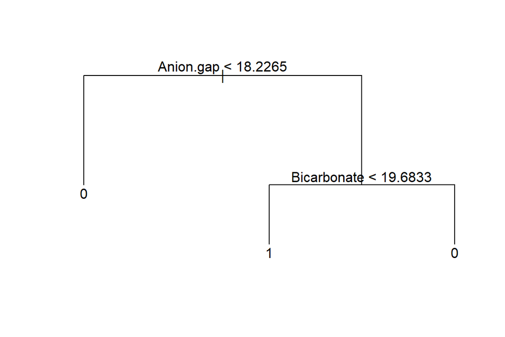

**Figure 6:** Pruned decision tree.

The pruned tree used just two splits, first on `Anion gap` and then on `Bicarbonate`. Patients with a low anion gap were predicted to survive, while those with a high anion gap and low bicarbonate were predicted to die. The simplicity of the tree is consistent with the low sensitivity observed in the results table since a model with only two splits has limited ability to capture the complexity of mortality prediction, particularly for a minority class.

### Random Forest Variable Importance

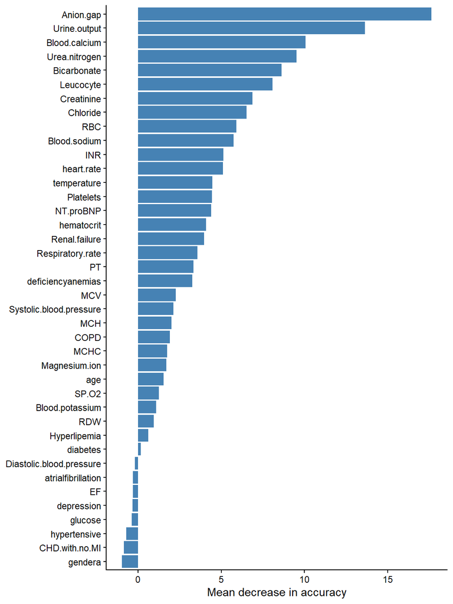

**Figure 7:** Mean decrease in accuracy for each predictor in the random forest.

`Anion.gap` was by far the most important predictor, consistent with it being the first split in the decision tree. `Bicarbonate` also ranked highly, consistent with its role as the second split in the decision tree, suggesting both variables have genuine predictive value beyond the tree alone. `Urine.output`, `Blood.calcium` and `Urea.nitrogen` also showed meaningful importance, suggesting a cluster of biochemical markers are most predictive of mortality. Several variables at the bottom of the plot showed importance near or below zero, particularly the binary comorbidity indicators such as `hypertensive`, `depression` and `atrialfibrillation`, suggesting they contributed little predictive signal, consistent with the EDA observation that most comorbidities were not clearly associated with mortality outcome.